# Week 4 Supplement

BL Mosby

2/6/2021

```r
r = getOption("repos")
r["CRAN"] = "http://cran.us.r-project.org"
options(repos = r)

library(tidyverse)
library(haven)
library(readxl)
```

## Correction to the Excel download from Async

Here are a few tweaks to the async code for the Excel file download that may run a bit smoother:

```r
## Web page:
##http://nces.ed.gov/programs/digest/d14/tables/dt14_204.10.asp

#If you have been getting an error with the download, add the mode argument (which directs RStudio to download as a binary file).
if(file.exists("free.xls")==FALSE){
  download.file("http://nces.ed.gov/programs/digest/d14/tables/xls/tabn204.10.xls",destfile="free.xls", mode="wb")
free<-read_excel("free.xls",skip=4,col_names=FALSE)
}else{
  free<-read_excel("free.xls",skip=4,col_names=FALSE)
}
```

```
## * `` -> ...1
## * `` -> ...2
## * `` -> ...3
## * `` -> ...4
## * `` -> ...5
## * ...
```

```r
head(free)
```

```
## # A tibble: 6 x 19
##   ...1    ...2 ...3    ...4   ...5 ...6    ...7   ...8 ...9   ...10  ...11 ...12
##   <chr>  <dbl> <chr>  <dbl>  <dbl> <chr>  <dbl>  <dbl> <chr>  <dbl>  <dbl> <chr>
## 1 Unit~ 4.66e7 "\\1~ 4.89e7 4.90e7 "\\1~ 4.91e7 1.78e7 "\\1~ 2.35e7 2.43e7 "\\1~
## 2 Alab~ 7.28e5  <NA> 7.30e5 7.32e5  <NA> 7.40e5 3.35e5  <NA> 4.02e5 4.20e5  <NA>
## 3 Alas~ 1.05e5  <NA> 1.32e5 1.31e5  <NA> 1.31e5 3.25e4  <NA> 5.07e4 5.32e4  <NA>
## 4 Ariz~ 8.78e5 "\\2~ 1.07e6 1.02e6  <NA> 9.90e5 2.74e5 "\\2~ 4.82e5 5.12e5  <NA>
## 5 Arka~ 4.50e5  <NA> 4.82e5 4.83e5  <NA> 4.86e5 2.05e5  <NA> 2.92e5 2.94e5  <NA>
## 6 Cali~ 6.05e6  <NA> 6.17e6 6.20e6 "\\2~ 6.18e6 2.82e6  <NA> 3.34e6 3.35e6 "\\2~
## # ... with 7 more variables: ...13 <dbl>, ...14 <dbl>, ...15 <chr>,
## #   ...16 <dbl>, ...17 <dbl>, ...18 <chr>, ...19 <dbl>
```

Next, to get rid of the empty rows and columns, you may need to adjust the column names to match what’s in your dataframe.

```r
# Now need to clean up
#Get rid of unwanted columns

free2<-free[ ,-(c(3,6,9,12,15,18))]

#Get rid of unwanted rows-- My column titles are "...1" so I will change the is.na argument to reflect that:
free2<-free2%>%filter(is.na(...1)==FALSE)
```

The rest of the code chunks for the Excel download should work as is.

## Zipped Files

Some data files that are very large are compressed into a zipped file (along with codebooks or other metadata files). These take a two step process, where you must also know the name of the data file within the zipped folder.

```r
#creating a temporary file to hold the zipped folder
temp <- tempfile()

#downloading the zipped folder from the data source webpage, and unzipping the SPSS data file
download.file("https://gss.norc.org/Documents/spss/GSS_2014_Merged_SPSS.zip", temp)
unzip(temp, "gss2014merged_r10 - spss.sav")

#reading in the spss command and closing the connection
gss14<-read_spss("gss2014merged_r10 - spss.sav")
unlink(temp)

head(gss14)
```

```
## # A tibble: 6 x 1,001
##    year    id wrkstat  hrs1  hrs2   evwork  wrkslf wrkgovt      OCC10 prestg10
##   <dbl> <dbl> <dbl+l> <dbl> <dbl> <dbl+lb> <dbl+l> <dbl+l>  <dbl+lbl> <dbl+lb>
## 1  2014     1 1 [WOR~    60    NA NA       1 [SEL~ 2 [PRI~  220 [Con~       53
## 2  2014     2 1 [WOR~    40    NA NA       2 [SOM~ 2 [PRI~  700 [Log~       51
## 3  2014     3 4 [UNE~    NA    NA NA       2 [SOM~ 2 [PRI~ 8740 [Ins~       39
## 4  2014     4 2 [WOR~    20    NA NA       2 [SOM~ 2 [PRI~   50 [Mar~       53
## 5  2014     5 5 [RET~    NA    NA  1 [YES] 2 [SOM~ 1 [GOV~  800 [Acc~       60
## 6  2014     6 1 [WOR~    60    NA NA       1 [SEL~ 2 [PRI~ 5000 [Fir~       46
## # ... with 991 more variables: prestg105plus <dbl+lbl>, INDUS10 <dbl+lbl>,
## #   marital <dbl+lbl>, martype <dbl+lbl>, divorce <dbl+lbl>, widowed <dbl+lbl>,
## #   spwrksta <dbl+lbl>, sphrs1 <dbl+lbl>, sphrs2 <dbl+lbl>, spevwork <dbl+lbl>,
## #   spwrkslf <dbl+lbl>, SPOCC10 <dbl+lbl>, sppres10 <dbl+lbl>,
## #   sppres105plus <dbl+lbl>, SPIND10 <dbl+lbl>, pawrkslf <dbl+lbl>,
## #   PAOCC10 <dbl+lbl>, papres10 <dbl+lbl>, papres105plus <dbl+lbl>,
## #   PAIND10 <dbl+lbl>, mawrkslf <dbl+lbl>, MAOCC10 <dbl+lbl>,
## #   mapres10 <dbl+lbl>, mapres105plus <dbl+lbl>, MAIND10 <dbl+lbl>,
## #   sibs <dbl+lbl>, childs <dbl+lbl>, age <dbl+lbl>, agekdbrn <dbl+lbl>,
## #   educ <dbl+lbl>, paeduc <dbl+lbl>, maeduc <dbl+lbl>, speduc <dbl+lbl>,
## #   degree <dbl+lbl>, padeg <dbl+lbl>, madeg <dbl+lbl>, spdeg <dbl+lbl>,
## #   major1 <dbl+lbl>, major2 <dbl+lbl>, DIPGED <dbl+lbl>, SPDIPGED <dbl+lbl>,
## #   whenhs <dbl+lbl>, whencol <dbl+lbl>, sector <dbl+lbl>, eftotlt <dbl+lbl>,
## #   barate <dbl+lbl>, gradtounder <dbl+lbl>, VOEDCOL <dbl+lbl>,
## #   VOEDNME1 <dbl+lbl>, VOEDNCOL <dbl+lbl>, VOEDNME2 <dbl+lbl>,
## #   spsector <dbl+lbl>, speftotlt <dbl+lbl>, spbarate <dbl+lbl>,
## #   spgradtounder <dbl+lbl>, sex <dbl+lbl>, race <dbl+lbl>, res16 <dbl+lbl>,
## #   reg16 <dbl+lbl>, mobile16 <dbl+lbl>, family16 <dbl+lbl>,
## #   famdif16 <dbl+lbl>, mawrkgrw <dbl+lbl>, incom16 <dbl+lbl>, born <dbl+lbl>,
## #   parborn <dbl+lbl>, granborn <dbl+lbl>, hompop <dbl+lbl>, babies <dbl+lbl>,
## #   preteen <dbl+lbl>, teens <dbl+lbl>, adults <dbl+lbl>, unrelat <dbl+lbl>,
## #   earnrs <dbl+lbl>, income <dbl+lbl>, rincome <dbl+lbl>, income06 <dbl+lbl>,
## #   rincom06 <dbl+lbl>, region <dbl+lbl>, xnorcsiz <dbl+lbl>,
## #   srcbelt <dbl+lbl>, size <dbl+lbl>, partyid <dbl+lbl>, VOTE08 <dbl+lbl>,
## #   PRES08 <dbl+lbl>, IF08WHO <dbl+lbl>, VOTE12 <dbl+lbl>, PRES12 <dbl+lbl>,
## #   IF12WHO <dbl+lbl>, polviews <dbl+lbl>, natspac <dbl+lbl>,
## #   natenvir <dbl+lbl>, natheal <dbl+lbl>, natcity <dbl+lbl>,
## #   natcrime <dbl+lbl>, natdrug <dbl+lbl>, nateduc <dbl+lbl>,
## #   natrace <dbl+lbl>, natarms <dbl+lbl>, nataid <dbl+lbl>, ...
```

## Homework 4 Exercises

For Assignment 4, replace #2 and #3 with the following:

2. U.S. National Election Survey data from 2004. Save as file name `nes.RData`. https://osf.io/zpuhd/download
3. General Social Survey (GSS), pick any of the individual year datasets (1972 - 2018). Save as file name `gss<year>.Rdata`. Note this will be an SPSS file within a zipped file, and you will need to use the code above. https://gss.norc.org/get-the-data/spss.

## Extra Excel data

My code for the additional Excel dataset from async. (Note, there is more than one correct way to go about cleaning the data.)

```r
## Web page:
##http://nces.ed.gov/programs/digest/d14/tables/dt14_204.10.asp

download.file("http://nces.ed.gov/programs/digest/d14/tables/xls/tabn302.10.xls",destfile="newxl.xls", mode="wb")

newxl<-read_excel("newxl.xls",skip=6,col_names=FALSE)
```

```
## * `` -> ...1
## * `` -> ...2
## * `` -> ...3
## * `` -> ...4
## * `` -> ...5
## * ...
```

```r
#Get rid of empty rows and unneeded columns.
newxl<-newxl%>%filter(is.na(...1)==FALSE)

newxl<-newxl[1:54,]
newxl<-newxl[ ,-(c(3,5,7,9,11,13,15,17,19,21,23,25))]


#Add useful names to the columns.
names(newxl)<-c("year", "hscomptotal", "hscompmales","hscompfemales","incollegetotal","total2y","total4y",  "collegetotalmales", "males2y",  "males4y", "collegetotalfemales",  "females2y",  "females4y")


#Change the year variable into a format that R can understand and drop the old one.
yeardate = seq(from = as.Date("1960-01-01"), to = as.Date("2013-01-01"), by = 'year')

newxl2<-cbind(yeardate, newxl)
newxl2<-newxl2[,-2]

head(newxl2)
```

```
##     yeardate hscomptotal hscompmales hscompfemales incollegetotal total2y
## 1 1960-01-01        1679         756           923       45.14592     ---
## 2 1961-01-01        1763         790           973       48.04311     ---
## 3 1962-01-01        1838         872           966       48.96627     ---
## 4 1963-01-01        1741         794           947       45.03159     ---
## 5 1964-01-01        2145         997          1148       48.34499     ---
## 6 1965-01-01        2659        1254          1405       50.92140     ---
##   total4y collegetotalmales males2y males4y collegetotalfemales females2y
## 1     ---          53.96825     ---     ---            37.91983       ---
## 2     ---          56.32911     ---     ---            41.31552       ---
## 3     ---          55.04587     ---     ---            43.47826       ---
## 4     ---          52.26700     ---     ---            38.96515       ---
## 5     ---          57.17151     ---     ---            40.67944       ---
## 6     ---          57.25678     ---     ---            45.26690       ---
##   females4y
## 1       ---
## 2       ---
## 3       ---
## 4       ---
## 5       ---
## 6       ---
```

This was just a graph I did for fun, to visualize one of the variables.

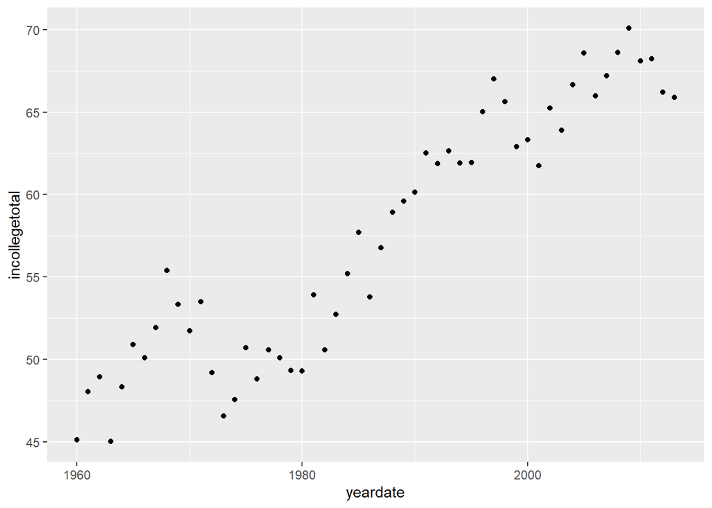

```r
gg<-ggplot(newxl2, aes(x=yeardate, y=incollegetotal))
gg<-gg+geom_point()
gg
```